# Risk Factor Analysis

## Outcome Variable

**Outcome Variable:** whz

## Predictor Variables

**Intervention Variable:** fage

**Adjustment Set:**

unadjusted

## Stratifying Variables

The analysis was stratified on these variable(s):

- agecat
- studyid
- country

## Data Summary

| agecat | studyid | country | fage | n_cell | n |
| --- | --- | --- | --- | --- | --- |
| Birth | ki0047075b-MAL-ED | BANGLADESH | >=38 | 65 | 140 |
| Birth | ki0047075b-MAL-ED | BANGLADESH | <32 | 25 | 140 |
| Birth | ki0047075b-MAL-ED | BANGLADESH | [32-38) | 50 | 140 |
| Birth | ki0047075b-MAL-ED | BRAZIL | >=38 | 25 | 65 |
| Birth | ki0047075b-MAL-ED | BRAZIL | <32 | 16 | 65 |
| Birth | ki0047075b-MAL-ED | BRAZIL | [32-38) | 24 | 65 |
| Birth | ki0047075b-MAL-ED | INDIA | >=38 | 26 | 128 |
| Birth | ki0047075b-MAL-ED | INDIA | <32 | 43 | 128 |
| Birth | ki0047075b-MAL-ED | INDIA | [32-38) | 59 | 128 |
| Birth | ki0047075b-MAL-ED | NEPAL | >=38 | 13 | 59 |
| Birth | ki0047075b-MAL-ED | NEPAL | <32 | 9 | 59 |
| Birth | ki0047075b-MAL-ED | NEPAL | [32-38) | 37 | 59 |
| Birth | ki0047075b-MAL-ED | PERU | >=38 | 27 | 78 |
| Birth | ki0047075b-MAL-ED | PERU | <32 | 26 | 78 |
| Birth | ki0047075b-MAL-ED | PERU | [32-38) | 25 | 78 |
| Birth | ki0047075b-MAL-ED | SOUTH AFRICA | >=38 | 52 | 75 |
| Birth | ki0047075b-MAL-ED | SOUTH AFRICA | <32 | 8 | 75 |
| Birth | ki0047075b-MAL-ED | SOUTH AFRICA | [32-38) | 15 | 75 |
| Birth | ki0047075b-MAL-ED | TANZANIA, UNITED REPUBLIC OF | >=38 | 20 | 44 |
| Birth | ki0047075b-MAL-ED | TANZANIA, UNITED REPUBLIC OF | <32 | 6 | 44 |
| Birth | ki0047075b-MAL-ED | TANZANIA, UNITED REPUBLIC OF | [32-38) | 18 | 44 |
| Birth | ki1000304b-SAS-CompFeed | INDIA | >=38 | 3 | 166 |
| Birth | ki1000304b-SAS-CompFeed | INDIA | <32 | 135 | 166 |
| Birth | ki1000304b-SAS-CompFeed | INDIA | [32-38) | 28 | 166 |
| Birth | ki1119695-PROBIT | BELARUS | >=38 | 606 | 13333 |
| Birth | ki1119695-PROBIT | BELARUS | <32 | 10676 | 13333 |
| Birth | ki1119695-PROBIT | BELARUS | [32-38) | 2051 | 13333 |
| Birth | ki1135781-COHORTS | GUATEMALA | >=38 | 222 | 735 |
| Birth | ki1135781-COHORTS | GUATEMALA | <32 | 337 | 735 |
| Birth | ki1135781-COHORTS | GUATEMALA | [32-38) | 176 | 735 |

[output cut: 75 more lines]

The following strata were considered:

- agecat: 24 months, studyid: ki0047075b-MAL-ED, country: BANGLADESH
- agecat: 24 months, studyid: ki0047075b-MAL-ED, country: BRAZIL
- agecat: 24 months, studyid: ki0047075b-MAL-ED, country: INDIA
- agecat: 24 months, studyid: ki0047075b-MAL-ED, country: NEPAL
- agecat: 24 months, studyid: ki0047075b-MAL-ED, country: PERU
- agecat: 24 months, studyid: ki0047075b-MAL-ED, country: SOUTH AFRICA
- agecat: 24 months, studyid: ki0047075b-MAL-ED, country: TANZANIA, UNITED REPUBLIC OF
- agecat: 24 months, studyid: ki1119695-PROBIT, country: BELARUS
- agecat: 24 months, studyid: ki1135781-COHORTS, country: GUATEMALA
- agecat: 24 months, studyid: ki1135781-COHORTS, country: PHILIPPINES
- agecat: 24 months, studyid: ki1148112-LCNI-5, country: MALAWI
- agecat: 6 months, studyid: ki0047075b-MAL-ED, country: BANGLADESH
- agecat: 6 months, studyid: ki0047075b-MAL-ED, country: BRAZIL
- agecat: 6 months, studyid: ki0047075b-MAL-ED, country: INDIA
- agecat: 6 months, studyid: ki0047075b-MAL-ED, country: NEPAL
- agecat: 6 months, studyid: ki0047075b-MAL-ED, country: PERU
- agecat: 6 months, studyid: ki0047075b-MAL-ED, country: SOUTH AFRICA
- agecat: 6 months, studyid: ki0047075b-MAL-ED, country: TANZANIA, UNITED REPUBLIC OF
- agecat: 6 months, studyid: ki1000304b-SAS-CompFeed, country: INDIA
- agecat: 6 months, studyid: ki1000304b-SAS-FoodSuppl, country: INDIA
- agecat: 6 months, studyid: ki1119695-PROBIT, country: BELARUS
- agecat: 6 months, studyid: ki1135781-COHORTS, country: GUATEMALA
- agecat: 6 months, studyid: ki1135781-COHORTS, country: PHILIPPINES
- agecat: 6 months, studyid: ki1148112-LCNI-5, country: MALAWI
- agecat: Birth, studyid: ki0047075b-MAL-ED, country: BANGLADESH
- agecat: Birth, studyid: ki0047075b-MAL-ED, country: BRAZIL
- agecat: Birth, studyid: ki0047075b-MAL-ED, country: INDIA
- agecat: Birth, studyid: ki0047075b-MAL-ED, country: NEPAL
- agecat: Birth, studyid: ki0047075b-MAL-ED, country: PERU
- agecat: Birth, studyid: ki0047075b-MAL-ED, country: SOUTH AFRICA
- agecat: Birth, studyid: ki0047075b-MAL-ED, country: TANZANIA, UNITED REPUBLIC OF
- agecat: Birth, studyid: ki1000304b-SAS-CompFeed, country: INDIA
- agecat: Birth, studyid: ki1119695-PROBIT, country: BELARUS
- agecat: Birth, studyid: ki1135781-COHORTS, country: GUATEMALA
- agecat: Birth, studyid: ki1135781-COHORTS, country: PHILIPPINES

### Dropped Strata

Some strata were dropped due to rare outcomes:

- agecat: Birth, studyid: ki1000304b-SAS-CompFeed, country: INDIA

## Methods Detail

We’re interested in the causal parameters $E[Y_a]$ for all values of $a \in \mathcal{A}$. These parameters represent the mean outcome if, possibly contrary to fact, we intervened to set all units to have $A=a$. Under the randomization and positivity assumptions, these are identified by the statistical parameters $\psi_a=E_W[E_{Y|A,W}(Y|A=a,W)]$. In addition, we’re interested in the mean of $Y$, $E[Y]$ under no intervention (the observed mean). We will estimate these parameters by using SuperLearner to fit the relevant likelihood factors – $E_{Y|A,W}(Y|A=a,W)$ and $p(A=a|W)$, and then updating our likelihood fit using a joint TMLE.

For unadjusted analyses ($W=\{\}$), initial likelihoods were estimated using Lrnr_glm to estimate the simple $E(Y|A)$ and Lrnr_mean to estimate $p(A)$. For adjusted analyses, a small library containing Lrnr_glmnet, Lrnr_xgboost, and Lrnr_mean was used.

Having estimated these parameters, we will then use the delta method to estimate relative risks and attributable risks relative to a prespecified baseline level of $A$.

# Results Detail

## Results Plots

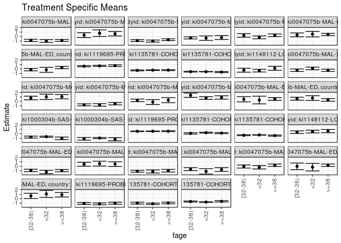

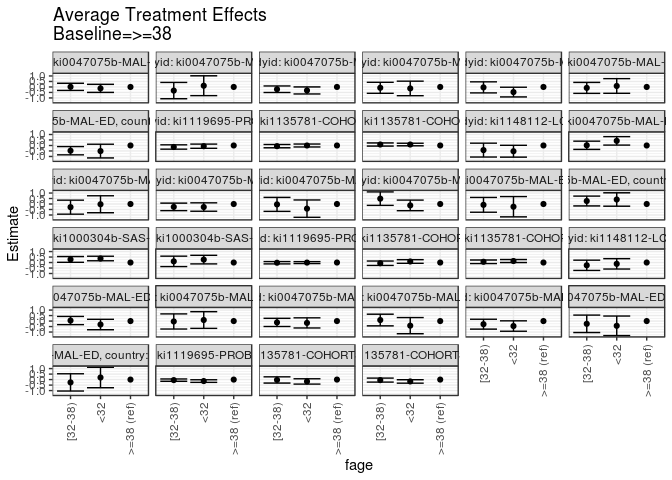

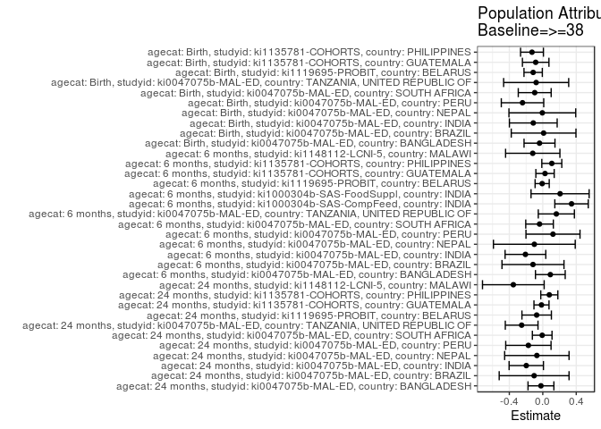

## Results Table

### Parameter: TSM

| agecat | studyid | country | intervention_level | baseline_level | estimate | ci_lower | ci_upper |
| --- | --- | --- | --- | --- | --- | --- | --- |
| Birth | ki0047075b-MAL-ED | BANGLADESH | >=38 | NA | -0.9890769 | -1.2518319 | -0.7263220 |
| Birth | ki0047075b-MAL-ED | BANGLADESH | <32 | NA | -1.3028000 | -1.6986906 | -0.9069094 |
| Birth | ki0047075b-MAL-ED | BANGLADESH | [32-38) | NA | -0.9418000 | -1.2056685 | -0.6779315 |
| Birth | ki0047075b-MAL-ED | BRAZIL | >=38 | NA | 0.4824000 | -0.0404014 | 1.0052014 |
| Birth | ki0047075b-MAL-ED | BRAZIL | <32 | NA | 0.5781250 | 0.0260538 | 1.1301962 |
| Birth | ki0047075b-MAL-ED | BRAZIL | [32-38) | NA | 0.4454167 | -0.0033237 | 0.8941570 |
| Birth | ki0047075b-MAL-ED | INDIA | >=38 | NA | -0.9980769 | -1.2996403 | -0.6965136 |
| Birth | ki0047075b-MAL-ED | INDIA | <32 | NA | -1.1665116 | -1.5152992 | -0.8177240 |
| Birth | ki0047075b-MAL-ED | INDIA | [32-38) | NA | -1.1216949 | -1.3382504 | -0.9051394 |
| Birth | ki0047075b-MAL-ED | NEPAL | >=38 | NA | -0.7415385 | -1.1600111 | -0.3230658 |
| Birth | ki0047075b-MAL-ED | NEPAL | <32 | NA | -1.1600000 | -1.7640146 | -0.5559854 |
| Birth | ki0047075b-MAL-ED | NEPAL | [32-38) | NA | -0.6481081 | -0.9759608 | -0.3202554 |
| Birth | ki0047075b-MAL-ED | PERU | >=38 | NA | 0.2259259 | -0.0534051 | 0.5052569 |
| Birth | ki0047075b-MAL-ED | PERU | <32 | NA | -0.2276923 | -0.6109150 | 0.1555303 |
| Birth | ki0047075b-MAL-ED | PERU | [32-38) | NA | -0.0580000 | -0.4119723 | 0.2959723 |
| Birth | ki0047075b-MAL-ED | SOUTH AFRICA | >=38 | NA | 0.2282692 | -0.0472275 | 0.5037660 |
| Birth | ki0047075b-MAL-ED | SOUTH AFRICA | <32 | NA | -0.2037500 | -1.0516357 | 0.6441357 |
| Birth | ki0047075b-MAL-ED | SOUTH AFRICA | [32-38) | NA | -0.0233333 | -0.7676448 | 0.7209781 |
| Birth | ki0047075b-MAL-ED | TANZANIA, UNITED REPUBLIC OF | >=38 | NA | 0.8760000 | 0.3647303 | 1.3872697 |
| Birth | ki0047075b-MAL-ED | TANZANIA, UNITED REPUBLIC OF | <32 | NA | 1.0650000 | 0.2867134 | 1.8432866 |
| Birth | ki0047075b-MAL-ED | TANZANIA, UNITED REPUBLIC OF | [32-38) | NA | 0.6194444 | 0.0212639 | 1.2176250 |
| Birth | ki1119695-PROBIT | BELARUS | >=38 | NA | -1.0259901 | -1.2564818 | -0.7954984 |
| Birth | ki1119695-PROBIT | BELARUS | <32 | NA | -1.1606285 | -1.3724720 | -0.9487850 |
| Birth | ki1119695-PROBIT | BELARUS | [32-38) | NA | -1.0732472 | -1.2842716 | -0.8622228 |
| Birth | ki1135781-COHORTS | GUATEMALA | >=38 | NA | -0.9731982 | -1.1649178 | -0.7814786 |
| Birth | ki1135781-COHORTS | GUATEMALA | <32 | NA | -1.1410386 | -1.2891827 | -0.9928945 |
| Birth | ki1135781-COHORTS | GUATEMALA | [32-38) | NA | -1.0061364 | -1.2166885 | -0.7955842 |
| Birth | ki1135781-COHORTS | PHILIPPINES | >=38 | NA | -0.6020792 | -0.7470952 | -0.4570633 |
| Birth | ki1135781-COHORTS | PHILIPPINES | <32 | NA | -0.7714891 | -0.8271174 | -0.7158609 |
| Birth | ki1135781-COHORTS | PHILIPPINES | [32-38) | NA | -0.6506628 | -0.7615030 | -0.5398226 |

[output cut: 72 more lines]

### Parameter: E(Y)

| agecat | studyid | country | intervention_level | baseline_level | estimate | ci_lower | ci_upper |
| --- | --- | --- | --- | --- | --- | --- | --- |
| Birth | ki0047075b-MAL-ED | BANGLADESH | NA | NA | -1.0282143 | -1.1991720 | -0.8572566 |
| Birth | ki0047075b-MAL-ED | BRAZIL | NA | NA | 0.4923077 | 0.1981785 | 0.7864369 |
| Birth | ki0047075b-MAL-ED | INDIA | NA | NA | -1.1116406 | -1.2776411 | -0.9456401 |
| Birth | ki0047075b-MAL-ED | NEPAL | NA | NA | -0.7467797 | -0.9945570 | -0.4990023 |
| Birth | ki0047075b-MAL-ED | PERU | NA | NA | -0.0162821 | -0.2170871 | 0.1845230 |
| Birth | ki0047075b-MAL-ED | SOUTH AFRICA | NA | NA | 0.1318667 | -0.1289649 | 0.3926982 |
| Birth | ki0047075b-MAL-ED | TANZANIA, UNITED REPUBLIC OF | NA | NA | 0.7968182 | 0.4398380 | 1.1537983 |
| Birth | ki1119695-PROBIT | BELARUS | NA | NA | -1.1410673 | -1.3516550 | -0.9304795 |
| Birth | ki1135781-COHORTS | GUATEMALA | NA | NA | -1.0580408 | -1.1607065 | -0.9553751 |
| Birth | ki1135781-COHORTS | PHILIPPINES | NA | NA | -0.7309760 | -0.7780724 | -0.6838797 |
| 6 months | ki0047075b-MAL-ED | BANGLADESH | NA | NA | -0.1977833 | -0.3606366 | -0.0349301 |
| 6 months | ki0047075b-MAL-ED | BRAZIL | NA | NA | 0.9393882 | 0.6572880 | 1.2214884 |
| 6 months | ki0047075b-MAL-ED | INDIA | NA | NA | -0.7206832 | -0.8692329 | -0.5721336 |
| 6 months | ki0047075b-MAL-ED | NEPAL | NA | NA | 0.1778270 | -0.0614697 | 0.4171237 |
| 6 months | ki0047075b-MAL-ED | PERU | NA | NA | 1.0140361 | 0.7785203 | 1.2495520 |
| 6 months | ki0047075b-MAL-ED | SOUTH AFRICA | NA | NA | 0.5153558 | 0.2512666 | 0.7794450 |
| 6 months | ki0047075b-MAL-ED | TANZANIA, UNITED REPUBLIC OF | NA | NA | 0.5034500 | 0.2959923 | 0.7109077 |
| 6 months | ki1000304b-SAS-CompFeed | INDIA | NA | NA | -0.6641059 | -0.8040033 | -0.5242086 |
| 6 months | ki1000304b-SAS-FoodSuppl | INDIA | NA | NA | -1.0121579 | -1.1280429 | -0.8962729 |
| 6 months | ki1119695-PROBIT | BELARUS | NA | NA | 0.5783069 | 0.5185614 | 0.6380524 |
| 6 months | ki1135781-COHORTS | GUATEMALA | NA | NA | 0.1925914 | 0.1205037 | 0.2646791 |
| 6 months | ki1135781-COHORTS | PHILIPPINES | NA | NA | -0.2878032 | -0.3296319 | -0.2459745 |
| 6 months | ki1148112-LCNI-5 | MALAWI | NA | NA | 0.5058491 | 0.3128980 | 0.6988001 |
| 24 months | ki0047075b-MAL-ED | BANGLADESH | NA | NA | -0.8861589 | -1.0281048 | -0.7442131 |
| 24 months | ki0047075b-MAL-ED | BRAZIL | NA | NA | 0.5441139 | 0.2074310 | 0.8807969 |
| 24 months | ki0047075b-MAL-ED | INDIA | NA | NA | -0.8977019 | -1.0295625 | -0.7658412 |
| 24 months | ki0047075b-MAL-ED | NEPAL | NA | NA | -0.2838608 | -0.4798646 | -0.0878569 |
| 24 months | ki0047075b-MAL-ED | PERU | NA | NA | 0.1203797 | -0.0839887 | 0.3247482 |
| 24 months | ki0047075b-MAL-ED | SOUTH AFRICA | NA | NA | 0.4538202 | 0.2465091 | 0.6611314 |
| 24 months | ki0047075b-MAL-ED | TANZANIA, UNITED REPUBLIC OF | NA | NA | 0.0766500 | -0.1115307 | 0.2648307 |
| 24 months | ki1119695-PROBIT | BELARUS | NA | NA | 0.6846323 | 0.5733690 | 0.7958955 |
| 24 months | ki1135781-COHORTS | GUATEMALA | NA | NA | -0.2760853 | -0.3311930 | -0.2209775 |
| 24 months | ki1135781-COHORTS | PHILIPPINES | NA | NA | -0.6087584 | -0.6459824 | -0.5715345 |
| 24 months | ki1148112-LCNI-5 | MALAWI | NA | NA | -0.1982432 | -0.4246666 | 0.0281801 |

### Parameter: ATE

| agecat | studyid | country | intervention_level | baseline_level | estimate | ci_lower | ci_upper |
| --- | --- | --- | --- | --- | --- | --- | --- |
| Birth | ki0047075b-MAL-ED | BANGLADESH | >=38 | >=38 | 0.0000000 | 0.0000000 | 0.0000000 |
| Birth | ki0047075b-MAL-ED | BANGLADESH | <32 | >=38 | -0.3137231 | -0.7888752 | 0.1614290 |
| Birth | ki0047075b-MAL-ED | BANGLADESH | [32-38) | >=38 | 0.0472769 | -0.3251029 | 0.4196568 |
| Birth | ki0047075b-MAL-ED | BRAZIL | >=38 | >=38 | 0.0000000 | 0.0000000 | 0.0000000 |
| Birth | ki0047075b-MAL-ED | BRAZIL | <32 | >=38 | 0.0957250 | -0.6646064 | 0.8560564 |
| Birth | ki0047075b-MAL-ED | BRAZIL | [32-38) | >=38 | -0.0369833 | -0.7259603 | 0.6519936 |
| Birth | ki0047075b-MAL-ED | INDIA | >=38 | >=38 | 0.0000000 | 0.0000000 | 0.0000000 |
| Birth | ki0047075b-MAL-ED | INDIA | <32 | >=38 | -0.1684347 | -0.6295130 | 0.2926436 |
| Birth | ki0047075b-MAL-ED | INDIA | [32-38) | >=38 | -0.1236180 | -0.4948817 | 0.2476457 |
| Birth | ki0047075b-MAL-ED | NEPAL | >=38 | >=38 | 0.0000000 | 0.0000000 | 0.0000000 |
| Birth | ki0047075b-MAL-ED | NEPAL | <32 | >=38 | -0.4184615 | -1.1532764 | 0.3163534 |
| Birth | ki0047075b-MAL-ED | NEPAL | [32-38) | >=38 | 0.0934304 | -0.4381773 | 0.6250380 |
| Birth | ki0047075b-MAL-ED | PERU | >=38 | >=38 | 0.0000000 | 0.0000000 | 0.0000000 |
| Birth | ki0047075b-MAL-ED | PERU | <32 | >=38 | -0.4536182 | -0.9278391 | 0.0206026 |
| Birth | ki0047075b-MAL-ED | PERU | [32-38) | >=38 | -0.2839259 | -0.7348386 | 0.1669867 |
| Birth | ki0047075b-MAL-ED | SOUTH AFRICA | >=38 | >=38 | 0.0000000 | 0.0000000 | 0.0000000 |
| Birth | ki0047075b-MAL-ED | SOUTH AFRICA | <32 | >=38 | -0.4320192 | -1.3235396 | 0.4595011 |
| Birth | ki0047075b-MAL-ED | SOUTH AFRICA | [32-38) | >=38 | -0.2516026 | -1.0452637 | 0.5420586 |
| Birth | ki0047075b-MAL-ED | TANZANIA, UNITED REPUBLIC OF | >=38 | >=38 | 0.0000000 | 0.0000000 | 0.0000000 |
| Birth | ki0047075b-MAL-ED | TANZANIA, UNITED REPUBLIC OF | <32 | >=38 | 0.1890000 | -0.7421964 | 1.1201964 |
| Birth | ki0047075b-MAL-ED | TANZANIA, UNITED REPUBLIC OF | [32-38) | >=38 | -0.2565556 | -1.0434588 | 0.5303477 |
| Birth | ki1119695-PROBIT | BELARUS | >=38 | >=38 | 0.0000000 | 0.0000000 | 0.0000000 |
| Birth | ki1119695-PROBIT | BELARUS | <32 | >=38 | -0.1346384 | -0.2529030 | -0.0163738 |
| Birth | ki1119695-PROBIT | BELARUS | [32-38) | >=38 | -0.0472571 | -0.1526231 | 0.0581089 |
| Birth | ki1135781-COHORTS | GUATEMALA | >=38 | >=38 | 0.0000000 | 0.0000000 | 0.0000000 |
| Birth | ki1135781-COHORTS | GUATEMALA | <32 | >=38 | -0.1678404 | -0.4101276 | 0.0744468 |
| Birth | ki1135781-COHORTS | GUATEMALA | [32-38) | >=38 | -0.0329382 | -0.3176988 | 0.2518225 |
| Birth | ki1135781-COHORTS | PHILIPPINES | >=38 | >=38 | 0.0000000 | 0.0000000 | 0.0000000 |
| Birth | ki1135781-COHORTS | PHILIPPINES | <32 | >=38 | -0.1694099 | -0.3247294 | -0.0140905 |
| Birth | ki1135781-COHORTS | PHILIPPINES | [32-38) | >=38 | -0.0485836 | -0.2311080 | 0.1339409 |

[output cut: 72 more lines]

### Parameter: PAR

| agecat | studyid | country | intervention_level | baseline_level | estimate | ci_lower | ci_upper |
| --- | --- | --- | --- | --- | --- | --- | --- |
| Birth | ki0047075b-MAL-ED | BANGLADESH | >=38 | NA | -0.0391374 | -0.2239561 | 0.1456814 |
| Birth | ki0047075b-MAL-ED | BRAZIL | >=38 | NA | 0.0099077 | -0.3768560 | 0.3966714 |
| Birth | ki0047075b-MAL-ED | INDIA | >=38 | NA | -0.1135637 | -0.3991369 | 0.1720095 |
| Birth | ki0047075b-MAL-ED | NEPAL | >=38 | NA | -0.0052412 | -0.4044175 | 0.3939351 |
| Birth | ki0047075b-MAL-ED | PERU | >=38 | NA | -0.2422080 | -0.4958428 | 0.0114268 |
| Birth | ki0047075b-MAL-ED | SOUTH AFRICA | >=38 | NA | -0.0964026 | -0.2930893 | 0.1002842 |
| Birth | ki0047075b-MAL-ED | TANZANIA, UNITED REPUBLIC OF | >=38 | NA | -0.0791818 | -0.4680239 | 0.3096603 |
| Birth | ki1119695-PROBIT | BELARUS | >=38 | NA | -0.1150772 | -0.2246239 | -0.0055305 |
| Birth | ki1135781-COHORTS | GUATEMALA | >=38 | NA | -0.0848426 | -0.2432496 | 0.0735644 |
| Birth | ki1135781-COHORTS | PHILIPPINES | >=38 | NA | -0.1288968 | -0.2656133 | 0.0078196 |
| 6 months | ki0047075b-MAL-ED | BANGLADESH | >=38 | NA | 0.0902722 | -0.0875374 | 0.2680819 |
| 6 months | ki0047075b-MAL-ED | BRAZIL | >=38 | NA | -0.1171118 | -0.4877257 | 0.2535021 |
| 6 months | ki0047075b-MAL-ED | INDIA | >=38 | NA | -0.2073962 | -0.4507033 | 0.0359109 |
| 6 months | ki0047075b-MAL-ED | NEPAL | >=38 | NA | -0.1009965 | -0.5898816 | 0.3878885 |
| 6 months | ki0047075b-MAL-ED | PERU | >=38 | NA | 0.1219991 | -0.2010100 | 0.4450082 |
| 6 months | ki0047075b-MAL-ED | SOUTH AFRICA | >=38 | NA | -0.0386546 | -0.2035480 | 0.1262388 |
| 6 months | ki0047075b-MAL-ED | TANZANIA, UNITED REPUBLIC OF | >=38 | NA | 0.1621306 | -0.0537096 | 0.3779707 |
| 6 months | ki1000304b-SAS-CompFeed | INDIA | >=38 | NA | 0.3438486 | 0.1440026 | 0.5436946 |
| 6 months | ki1000304b-SAS-FoodSuppl | INDIA | >=38 | NA | 0.2068421 | -0.1404449 | 0.5541291 |
| 6 months | ki1119695-PROBIT | BELARUS | >=38 | NA | -0.0073493 | -0.0918023 | 0.0771036 |
| 6 months | ki1135781-COHORTS | GUATEMALA | >=38 | NA | 0.0268668 | -0.0828129 | 0.1365464 |
| 6 months | ki1135781-COHORTS | PHILIPPINES | >=38 | NA | 0.1077821 | -0.0116230 | 0.2271871 |
| 6 months | ki1148112-LCNI-5 | MALAWI | >=38 | NA | -0.1199202 | -0.4446653 | 0.2048249 |
| 24 months | ki0047075b-MAL-ED | BANGLADESH | >=38 | NA | -0.0218836 | -0.1764786 | 0.1327114 |
| 24 months | ki0047075b-MAL-ED | BRAZIL | >=38 | NA | -0.1035527 | -0.5210653 | 0.3139598 |
| 24 months | ki0047075b-MAL-ED | INDIA | >=38 | NA | -0.1972852 | -0.4025671 | 0.0079967 |
| 24 months | ki0047075b-MAL-ED | NEPAL | >=38 | NA | -0.0709196 | -0.4559296 | 0.3140904 |
| 24 months | ki0047075b-MAL-ED | PERU | >=38 | NA | -0.1721203 | -0.4430654 | 0.0988249 |
| 24 months | ki0047075b-MAL-ED | SOUTH AFRICA | >=38 | NA | -0.0070259 | -0.1244623 | 0.1104104 |
| 24 months | ki0047075b-MAL-ED | TANZANIA, UNITED REPUBLIC OF | >=38 | NA | -0.2526208 | -0.4480348 | -0.0572069 |
| 24 months | ki1119695-PROBIT | BELARUS | >=38 | NA | -0.0731518 | -0.2492158 | 0.1029122 |
| 24 months | ki1135781-COHORTS | GUATEMALA | >=38 | NA | -0.0154929 | -0.1054222 | 0.0744363 |
| 24 months | ki1135781-COHORTS | PHILIPPINES | >=38 | NA | 0.0780313 | -0.0239722 | 0.1800347 |
| 24 months | ki1148112-LCNI-5 | MALAWI | >=38 | NA | -0.3520528 | -0.7207097 | 0.0166042 |